# class08

Sanghun Lee

June 10, 2019

### Visualizing data with UK food data. Principal Component Analysis (PCA) is used here.

```r
uk.foods <- read.csv("UK_foods.csv")
```

Viewing and trimming our UK foods data using R

```r
dim(uk.foods)
```

```
## [1] 17  5
```

```r
summary(uk.foods) # Presence of "x" in the first column.
```

```
##                  X         England           Wales           Scotland
##  Alcoholic_drinks : 1   Min.   :  54.0   Min.   :  64.0   Min.   :  53.0
##  Beverages        : 1   1st Qu.: 156.0   1st Qu.: 175.0   1st Qu.: 147.0
##  Carcass_meat     : 1   Median : 253.0   Median : 265.0   Median : 242.0
##  Cereals          : 1   Mean   : 469.6   Mean   : 503.9   Mean   : 460.2
##  Cheese           : 1   3rd Qu.: 685.0   3rd Qu.: 803.0   3rd Qu.: 566.0
##  Confectionery    : 1   Max.   :1472.0   Max.   :1582.0   Max.   :1572.0
##  (Other)          :11
##    N.Ireland
##  Min.   :  41.0
##  1st Qu.: 135.0
##  Median : 209.0
##  Mean   : 429.9
##  3rd Qu.: 586.0
##  Max.   :1506.0
##
```

```r
rownames(uk.foods) <- uk.foods[,1]
uk.foods <- uk.foods[,-1]

head(uk.foods) # x is gone.
```

```
##                England Wales Scotland N.Ireland
## Cheese             105   103      103        66
## Carcass_meat       245   227      242       267
## Other_meat         685   803      750       586
## Fish               147   160      122        93
## Fats_and_oils      193   235      184       209
## Sugars             156   175      147       139
```

The rownames function allows us to set the row names of our data frame as the first column values of this data frame. In this case, that would be the various kinds of food (Cheese, Carcass_meat, etc.).

The following code accomplishes the exact same goal, albeit more efficient.

```r
uk.foods <- read.csv("UK_foods.csv", row.names = 1)

uk.foods
```

```
##                     England Wales Scotland N.Ireland
## Cheese                  105   103      103        66
## Carcass_meat            245   227      242       267
## Other_meat              685   803      750       586
## Fish                    147   160      122        93
## Fats_and_oils           193   235      184       209
## Sugars                  156   175      147       139
## Fresh_potatoes          720   874      566      1033
## Fresh_Veg               253   265      171       143
## Other_Veg               488   570      418       355
## Processed_potatoes      198   203      220       187
## Processed_Veg           360   365      337       334
## Fresh_fruit            1102  1137      957       674
## Cereals                1472  1582     1462      1494
## Beverages                57    73       53        47
## Soft_drinks            1374  1256     1572      1506
## Alcoholic_drinks        375   475      458       135
## Confectionery            54    64       62        41
```

#### Class Question: Which approach to solving the ‘row-names problem’ mentioned above do you prefer and why? Is one approach more robust than another under certain circumstances?

The first code chunk (uk.foods <- uk.foods[,-1]) can delete columns that we may need.

The second code chunk (read.csv(file.name, row.names = n)) can be difficult to use if the data layout is more complicated than the example.

I personally prefer the 2nd method.

### Spotting major difference and trends

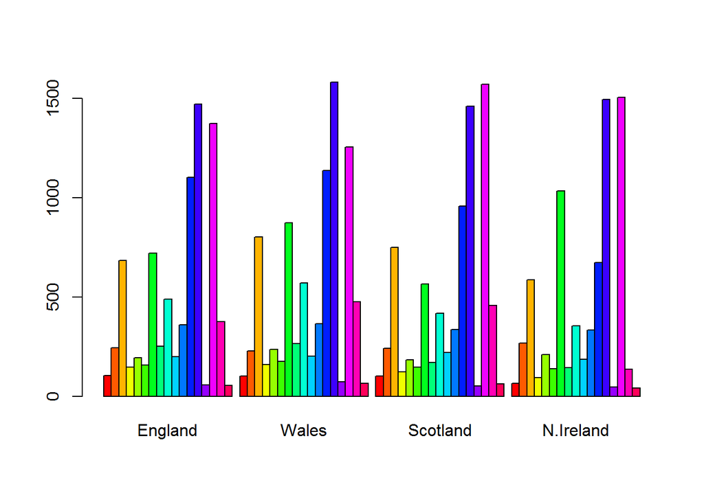

```r
barplot(as.matrix(uk.foods), beside = T, col = rainbow(nrow(uk.foods)))
```

The “beside” parameter. This parameter allows us to visualize each data ‘besides’ each other. Setting this to FALSE will produce a stacked column chart.

```r
#barplot(as.matrix(uk.foods), beside = F, col = rainbow(nrow(uk.foods)))
```

#### Class question: Generating all pairwise plots may help somewhat. Can you make sense of the following code and resulting figure? What does it mean if a given point lies on the diagonal for a given plot?

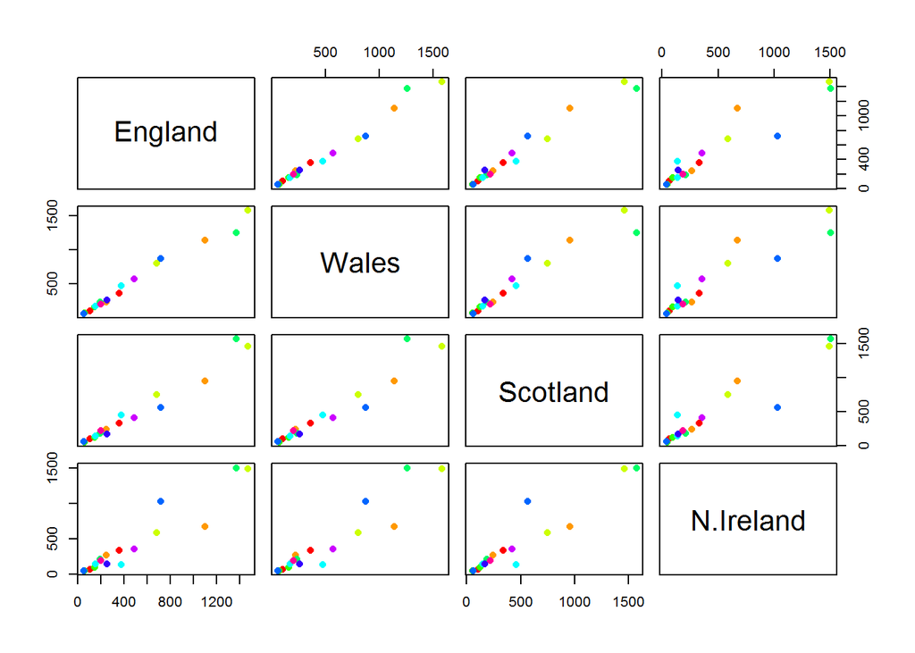

```r
pairs(uk.foods, col = rainbow(10), pch = 16)
```

### PCA to the rescue

Usage of prcomp() function and constructing a PCA dataset.

```r
pca <- prcomp(t(uk.foods))
summary(pca)
```

```
## Importance of components:
##                             PC1      PC2      PC3       PC4
## Standard deviation     324.1502 212.7478 73.87622 4.189e-14
## Proportion of Variance   0.6744   0.2905  0.03503 0.000e+00
## Cumulative Proportion    0.6744   0.9650  1.00000 1.000e+00
```

t() function is the “transpose” fucntion. This switches the row and the columns in a data frame.

Generating a plot of PC1 vs. PC2.

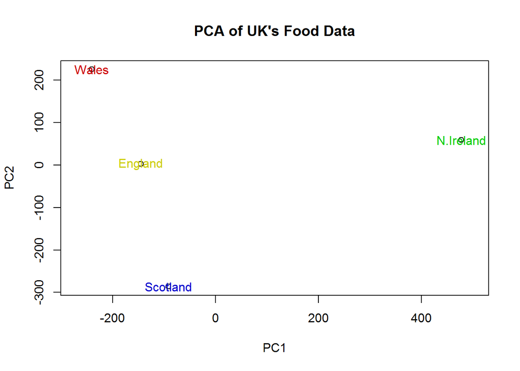

```r
plot(pca$x[,1], pca$x[,2], xlab = "PC1", ylab = "PC2", xlim = c(-270, 500),
     main = "PCA of UK's Food Data")

colvec = c("yellow3", "red3", 'blue3', 'green3')

text(pca$x[,1], pca$x[,2], colnames(uk.foods), col = colvec)
```

With this chunk, I am understanding how much variation in each PC accounts for.

```r
v <- round(pca$sdev^2 / sum(pca$sdev^2) * 100)
v
```

```
## [1] 67 29  4  0
```

```r
z <- summary(pca)
z$importance
```

```
##                              PC1       PC2      PC3          PC4
## Standard deviation     324.15019 212.74780 73.87622 4.188568e-14
## Proportion of Variance   0.67444   0.29052  0.03503 0.000000e+00
## Cumulative Proportion    0.67444   0.96497  1.00000 1.000000e+00
```

From the R code chunk, we can see that PC1 accounts for 67% of the variation in the data, and PC2 accounts for 29%. Generally speaking, almost all the variation in the data will be captured by PC1 and PC2.

Graphing the variation in our PCA.

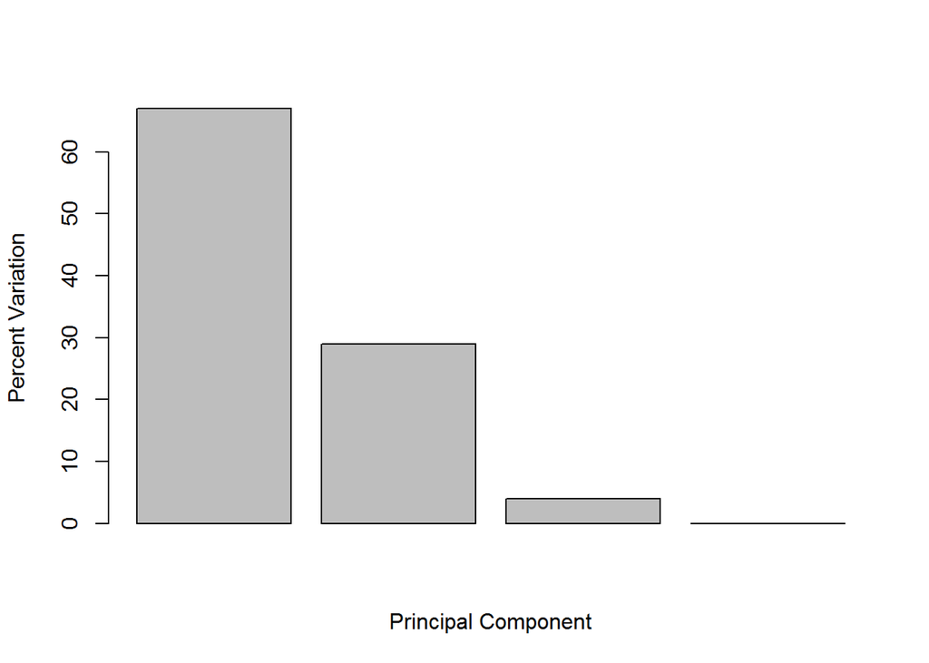

```r
barplot(v, xlab = "Principal Component", ylab = "Percent Variation")
```

### Digging deeper into understanding PCA.

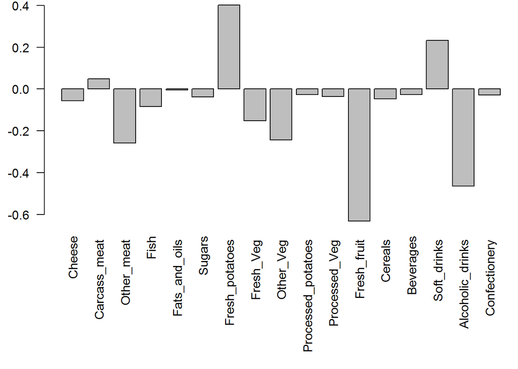

```r
par(mar = c(10, 3, 0.35, 0))
barplot(pca$rotation[,1], las = 2)
```

par(mar = c()) sets the plot’s dimensions. This is to clean up our barplot or plot function.

pca$rotation, or rotation, is called “loading scores”. This loading scores help us to determine which components have the largest effect on where they are plotted in the PCA plot.

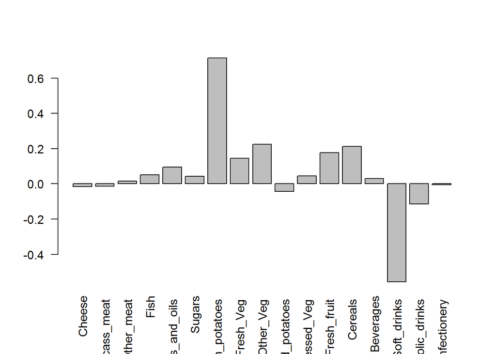

```
##       [,1]
##  [1,]  0.7
##  [2,]  1.9
##  [3,]  3.1
##  [4,]  4.3
##  [5,]  5.5
##  [6,]  6.7
##  [7,]  7.9
##  [8,]  9.1
##  [9,] 10.3
## [10,] 11.5
## [11,] 12.7
## [12,] 13.9
## [13,] 15.1
## [14,] 16.3
## [15,] 17.5
## [16,] 18.7
## [17,] 19.9
```

```r
(barplot(pca$rotation[,2], las = 2))
```

Constructing Biplots

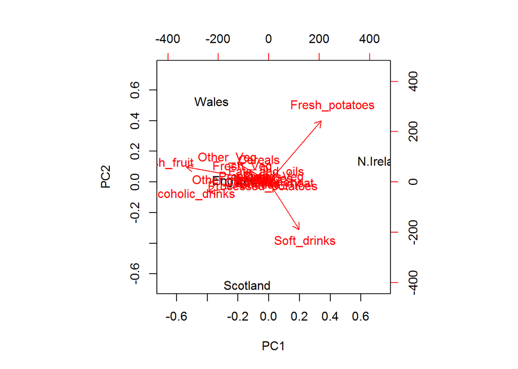

```r
biplot(pca)
```

A biplot represents a sample as a point on the graph (Eng, Scot, Wales, N.Ire), and variables as a vector (cheese, carcass_meat, confectionary, etc.).

### PCA of RNA-Seq data

```r
rna.data <- read.csv("expression.csv", row.names = 1)
head(rna.data)
```

```
##        wt1 wt2  wt3  wt4 wt5 ko1 ko2 ko3 ko4 ko5
## gene1  439 458  408  429 420  90  88  86  90  93
## gene2  219 200  204  210 187 427 423 434 433 426
## gene3 1006 989 1030 1017 973 252 237 238 226 210
## gene4  783 792  829  856 760 849 856 835 885 894
## gene5  181 249  204  244 225 277 305 272 270 279
## gene6  460 502  491  491 493 612 594 577 618 638
```

Class question: How many genes and samples are in this data set?

```r
nrow(rna.data)
```

```
## [1] 100
```

```r
ncol(rna.data)
```

```
## [1] 10
```

We have 100 genes each with 10 samples.

#### Generating a plot for this new RNA-Seq data.

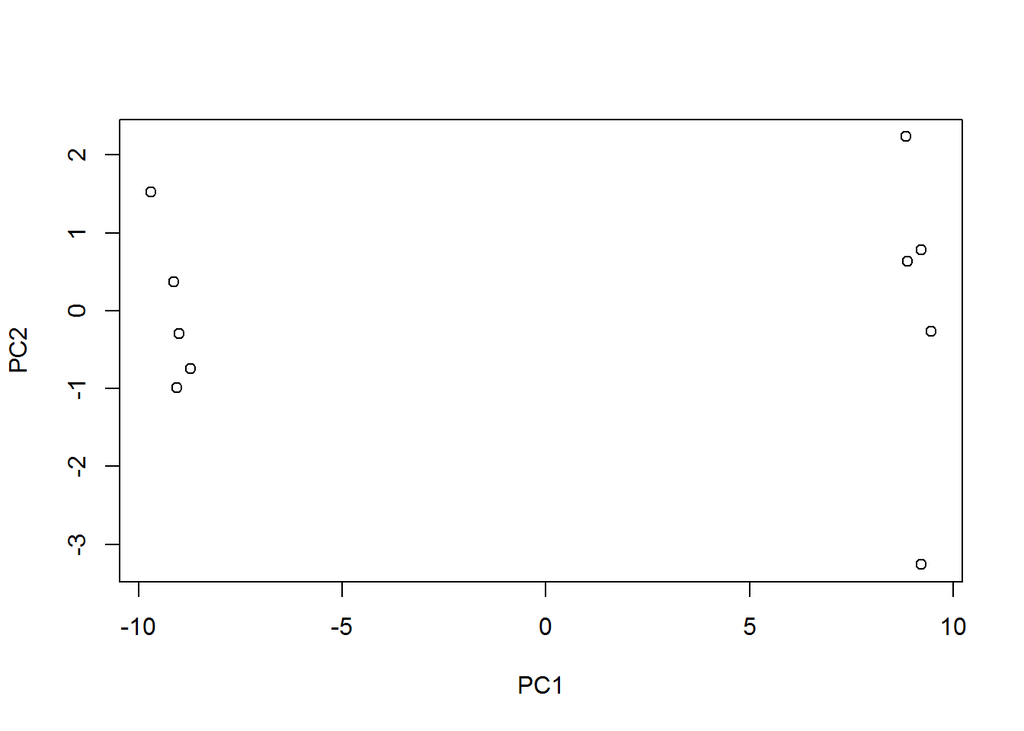

```r
pca.rna <- prcomp(t(rna.data), scale = T)

plot(pca.rna$x[,1], pca.rna$x[,2],
     xlab = "PC1",
     ylab = "PC2")
```

Interesting how there is a clear divide between two groups of data frame.

PCA variance percentage calculation

```r
pca.var <- pca.rna$sdev^2
pca.var.per <- round(pca.var/sum(pca.var)*100, 1)

pca.var.per
```

```
##  [1] 92.6  2.3  1.1  1.1  0.8  0.7  0.6  0.4  0.4  0.0
```

Barplot of PCA variance percentage

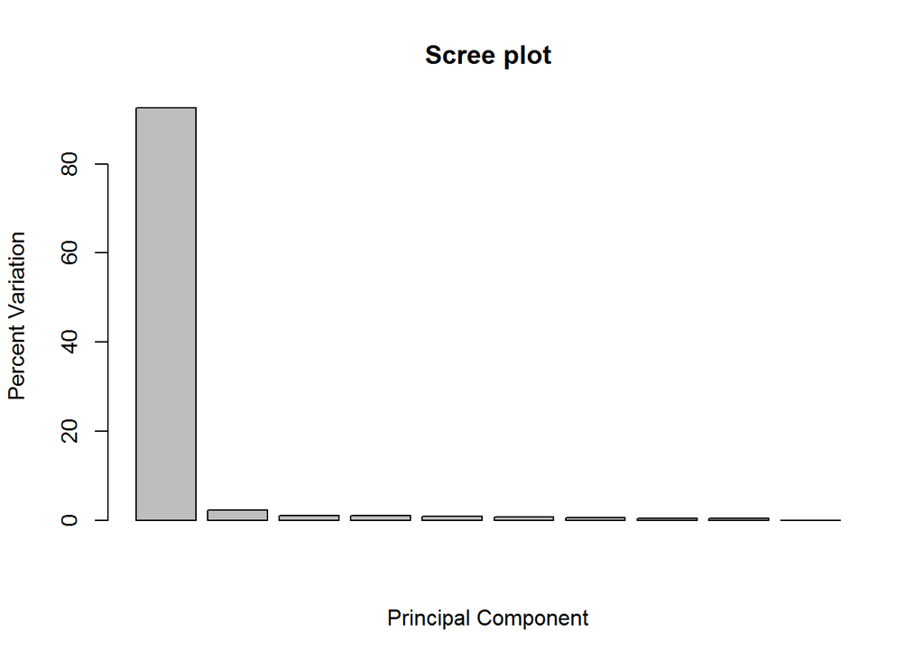

```r
barplot(pca.var.per, main = 'Scree plot',
        xlab = "Principal Component",
        ylab = "Percent Variation")
```

We can see from this that all the action (variance) is in PC1. PC1 accounts for almost 93% of the variance in the data.

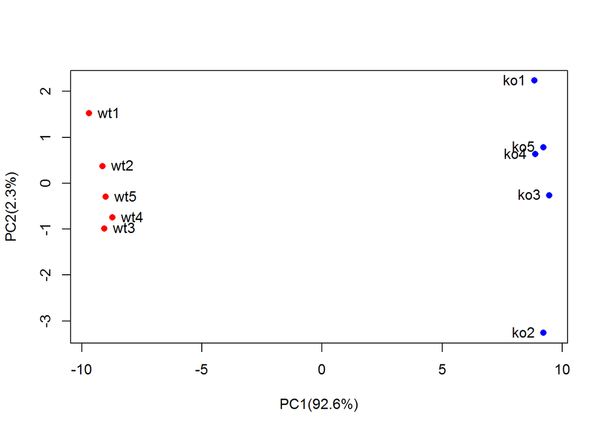

```r
colvec <- colnames(rna.data)
colvec[grep("wt", colvec)] <- "red"
colvec[grep("ko", colvec)] <- "blue"

plot(pca.rna$x[,1], pca.rna$x[,2], col = colvec, pch = 16,
     xlab = paste0("PC1(", pca.var.per[1], "%)"),
     ylab = paste0("PC2(", pca.var.per[2], "%)"))

text(pca.rna$x[,1], pca.rna$x[,2], labels = colnames(rna.data), pos = c(rep(4,5), rep(2,5)))
```

Easier method to color in our dot plot.

```r
sample.type <- substr(colnames(rna.data), 1,2)
sample.type
```

```
##  [1] "wt" "wt" "wt" "wt" "wt" "ko" "ko" "ko" "ko" "ko"
```

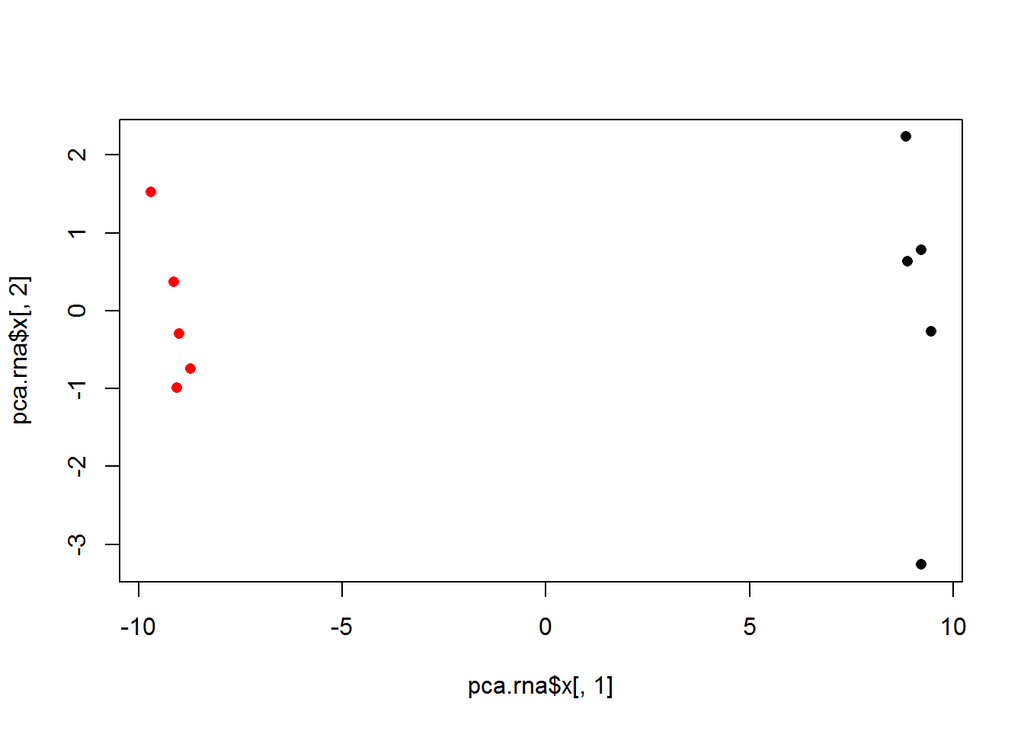

```r
plot(pca.rna$x[,1], pca.rna$x[,2], col = as.factor(sample.type), pch = 16)
```

Finding genes that contribute most to our PCA plot.

```r
gene.scores <- abs(pca.rna$rotation[,1])
gene.scores.ranked <- sort(gene.scores, decreasing = T)

top.10.genes <- names(gene.scores.ranked[1:10])
top.10.genes
```

```
##  [1] "gene100" "gene66"  "gene45"  "gene68"  "gene98"  "gene60"  "gene21"
##  [8] "gene56"  "gene10"  "gene90"
```

The above genes are affected by an abs() function, which applies an absolute value to all the values in a vector.

This is because a gene with a rotation score of 2.6 has a lesser effect on PCA when compared to a gene with a rotation score of -10.6.